# Fixed loci CNV calling filtering tree

Simone Montalbano

Wed Jun 30 13:41:04 2021

# Introduction

The focus is PennCNV calls, or any other software, given the availability of the three following global qality scores: BAF drift, LRR SD, GC Waviness Factor.

This is a graphical representation of a CNV calling pipeline in fixed genomic loci. The packege implement a filtering step just before visual inspection.

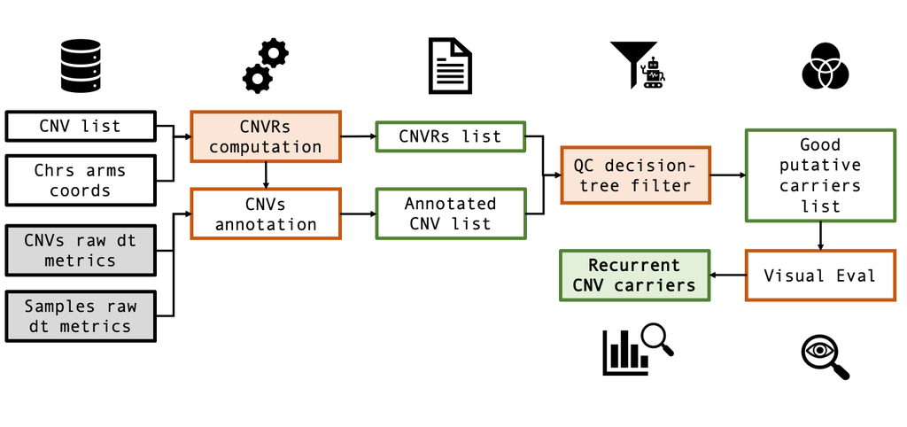

CNV calling pipeline

# Setup

To install and load the latest version of the package you can run the following code:

```r
devtools::install_github("SinomeM/QCtreeCNV")
library(QCtreeCNV)
```

# Data Format

1. a `data.frame` (bonus if already `data.table`) containing the putative CNV carriers calls;
2. a `data.frame` (bonus if already `data.table`) containing the required quality metrics, it can be created using provided functions;
3. a `data.table` containing CNVRs info, this is computed by a package function.

Additionally the package will compute CNVRs (starting from table 1).

We provide functions to create the quality metrics table starting from:

1. the raw intensity files;
2. genomic coordinates of the loci of interest;
3. a table to link samples ID to the raw intensity files.

Specifications on each object is given in the following sections. We tried to keep some sort of consistency with PennCNV format when possible.

## CNV calls

### Format

| Column Name | Format | Notes |
| --- | --- | --- |
| sample_ID |  | _ |
| locus |  | e.g. 22q11.2 |
| chr |  | e.g. chr1 |
| start |  | _ |
| stop |  | _ |
| type |  | “deletion”/“duplication” |
| CNVR_ID |  | this columns is added by the package |

## Quality metrics / Raw data trends

### Format

| Column Name | Format | Notes |
| --- | --- | --- |
| sample_ID |  | _ |
| locus |  | _ |
| put_carrier |  | is the sample a putative carrier for this locus?* |
| logr1 |  | _ |
| LRRSDlocus |  | _ |
| BAFc |  | _ |
| BAFb |  | _ |
| centDistProp |  | _ |
| overlapProp |  | _ |
| BAFdrift |  | _ |
| LRRSD |  | _ |
| GCWF |  | _ |

*: Currently if the table is created using the provided functions one line is created for each sample/locus combination, even if the sample is a putative carrier only for one specific locus. Note however that this is not mandatory, it is for done mostly to reuse computation time in downstream efficacy measures.

## CNVRs

### Format

| Column name | Format | Notes |
| --- | --- | --- |
| CNVR_ID |  | _ |
| chr |  | e.g. chr1 |
| start |  | _ |
| stop |  | _ |
| freq |  | _ |

# Run the Pipeline

The package has two main functions:

1. `computeCNVRs()` clusterize CNVs into CNV Regions;
2. `qctree()` runs the filtering pipeline;

In principle one could also use a different method to create CNVRs, as long as the output format is compatible to the `QCtreeCNV` one.